# EDA - CEAP

## Os Dados

```r
data %>% glimpse()
```

```
## Observations: 963,452
## Variables: 14
## $ nomeParlamentar <chr> "ABEL MESQUITA JR.", "ABEL MESQUITA JR.", "ABE...
## $ idCadastro      <int> 178957, 178957, 178957, 178957, 178957, 178957...
## $ sgUF            <chr> "RR", "RR", "RR", "RR", "RR", "RR", "RR", "RR"...
## $ sgPartido       <chr> "DEM", "DEM", "DEM", "DEM", "DEM", "DEM", "DEM...
## $ tipoDespesa     <chr> "MANUTENÇÃO DE ESCRITÓRIO DE APOIO À ATIVIDADE...
## $ especDespesa    <chr> NA, NA, NA, NA, NA, "Veículos Automotores", "V...
## $ fornecedor      <chr> "COMPANHIA DE AGUAS E ESGOTOS DE RORAIMA", "CO...
## $ CNPJCPF         <chr> "05939467000115", "05939467000115", "023414700...
## $ tipoDocumento   <int> 0, 0, 0, 0, 0, 0, 0, 0, 0, 0, 0, 0, 0, 0, 0, 0...
## $ dataEmissao     <chr> "2015-11-14 00:00:00", "2015-12-10 00:00:00", ...
## $ valorDocumento  <dbl> 165.65, 59.48, 130.95, 196.53, 310.25, 32.00, ...
## $ valorGlosa      <int> 0, 0, 0, 347, 0, 0, 0, 0, 0, 0, 0, 0, 0, 0, 0,...
## $ valorLíquido    <dbl> 165.65, 59.48, 130.95, 193.06, 310.25, 32.00, ...
## $ limiteMensal    <dbl> 45612.53, 45612.53, 45612.53, 45612.53, 45612....
```

Para a nossa análise iremos utilizar dados sobre as despesas dos deputados federais da legislatura atual com a atividade parlamentar. Para isso usaremos os dados do CEAP, que é uma cota única mensal destinada a custear os gastos dos deputados exclusivamente vinculados ao exercício da atividade parlamentar.

Os dados foram coletados no site de transparência da Câmara.

### Descrição das variáveis

No nosso conjunto de dados nós temos 14 variáveis:

#### nomeParlamentar

```
Nome adotado pelo Parlamentar ao tomar posse do seu mandato.
```

#### idCadastro

```
Número que identifica unicamente um deputado federal na CD.
```

#### sgUF

```
No contexto da cota CEAP, representa a unidade da federação pela qual o deputado foi eleito e é utilizada para definir o valor da cota a que o deputado tem.
```

#### sgPartido

```
Sigla do partido do parlamentar.
```

#### tipoDespesa

```
O seu conteúdo é a descrição do Tipo de Despesa relativo à despesa em questão.
```

#### especDespesa

```
Representa a descrição  especificação mais detalhada de um referido Tipo de Despesa.
```

#### fornecedor

```
O conteúdo deste dado representa o nome do fornecedor do produto ou serviço presente no documento fiscal
```

#### CNPJCPF

```
O conteúdo deste dado representa o CNPJ ou o CPF do emitente do documento fiscal, quando se tratar do uso da cota em razão do reembolso despesas comprovadas pela emissão de documentos fiscais.
```

### tipoDocumento

```
Este dado representa o tipo de documento do fiscal – 0 (Zero), para Nota Fiscal; 1 (um), para Recibo; e 2, para Despesa no Exterior.
```

### dataEmissao

```
O conteúdo deste dado é a data de emissão do documento fiscal ou a data do documento que tenha dado causa à despesa.
```

#### valorDocumento

[output not shown]

#### valorGlosa

```
O seu conteúdo representa o valor da glosa do documento fiscal que incidirá sobre o Valor do Documento, ou o valor da glosa do documento que deu causa à despesa.
```

#### valorLiquido

[output not shown]

#### limiteMensal

```
O seu conteúdo representa o límite mensal de CEAP para o estado (UF) do parlamentar.
```

# Perguntas

## Quais são os deputados que gastaram mais dinheiro da CEAP? Quais são os mais econômicos?

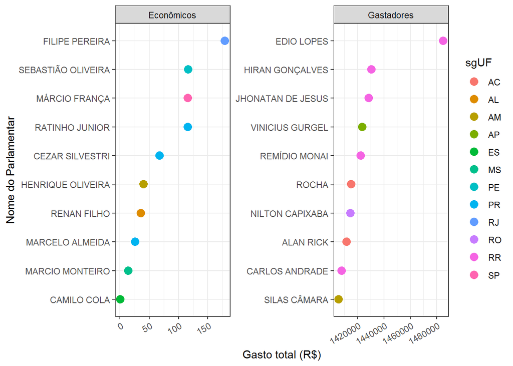

```r
data %>%
    group_by(sgUF,
             idCadastro,
             nomeParlamentar) %>%
    summarize(valorTotal = sum(valorLíquido)) %>%
    ungroup() %>%
    filter(valorTotal >= 0) %>%
    arrange(valorTotal) %>%
    slice(c(1:10, (n()-9):n())) %>%
    mutate(medianaGasto = mean(valorTotal), gastaMuito = if_else(valorTotal > medianaGasto, "Gastadores", "Econômicos")) %>%
    ggplot(aes(x = valorTotal,
               y = reorder(nomeParlamentar, valorTotal))) +
    geom_point(aes(color = sgUF), size = 3.5) +
    theme(axis.text.x = element_text(angle = 30,
                                     hjust = 1)) +
    labs(x = "Gasto total (R$)",
         y = "Nome do Parlamentar",
         fill = "Sigla do Estado") +
    facet_wrap(~gastaMuito, scales = "free")
```

Há casos em que os gastos são negativos, principalmente quando se trata de bilhetes aéreos pois podem significar um bilhete de compensação, pois compensa um outro bilhete emitido e não utilizado pelo parlamentar. E para evitar tais tratamentos, filtramos os parlamentares que possuíam a soma de seus gastos maior ou igual a 0 (`valorTotal >= 0`).

Na visualização é possível perceber 2 grupos de 10 parlamentares, um grupo é de parlamentares **econômicos** e o outro de parlamentares **gastadores**. Na primeira olhada conseguimos perceber que há uma enorme diferença entre os dois grupos, enquanto o maior gasto dos **econômicos** é de `R$ 179,18` o menor gasto dos **gastadores** é de `R$ 1.405.644,19`.

O mais gastador é **EDIO LOPES** e o mais econômico é **CAMILO COLA**.

## Quais os estados cujos deputados gastam mais no exterior? Quais os estados cujos deputados gastam menos no exterior?

Os gastos com despesas no exterior são caracterizados por ter o `tipoDocumento` com valor 2, portanto, aplicaremos um filtro nos nossos dados para realizar a visualização.

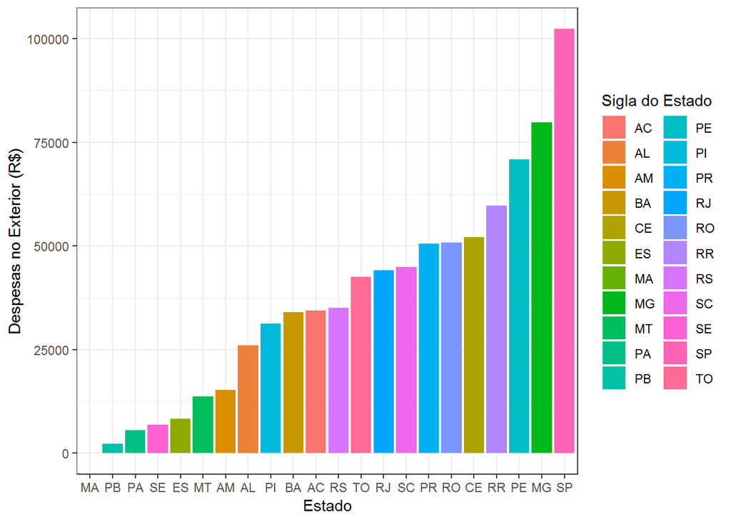

```r
data %>%
  filter(tipoDocumento == 2) %>%
  group_by(sgUF) %>%
  summarize(gastoExterior = sum(valorLíquido)) %>%
  ggplot(aes(x = reorder(sgUF, gastoExterior),
             y = gastoExterior,
             fill = sgUF)) +
  geom_bar(stat = "identity") +
  labs(x = "Estado",
       y = "Despesas no Exterior (R$)",
       fill = "Sigla do Estado")
```

Com a visualização acima conseguimos perceber que os estados que mais gastam no exterior são **SP (São Paulo)**, **MG (Minas Gerais)** e **PE (Pernambuco)** enquanto os que menos gastam são **MA (Maranhão)**, **PB (Paraíba)** e **PA (Pará)**.

## Quais os partidos cujos parlamentares mais usam CEAP no estado da Paraíba? Quais são os que menos usam? Mesmas perguntas considerando valores em R$.

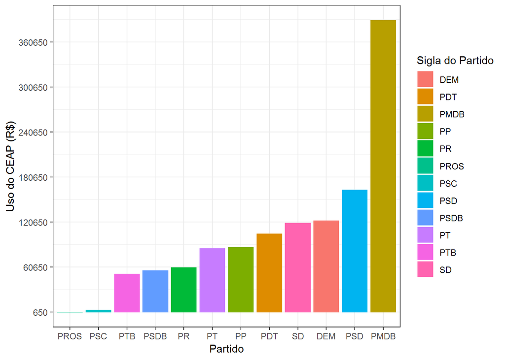

```r
data %>%
  filter(sgUF == "PB") %>%
  na.omit(sgUF,
          sgPartido,
          valorLíquido) %>%
  group_by(sgPartido) %>%
  summarize(gastoTotal = sum(valorLíquido)) %>%
  ggplot(aes(x = reorder(sgPartido, gastoTotal),
             y = gastoTotal,
             fill = sgPartido)) +
  geom_bar(stat = "identity") +
  scale_y_continuous(breaks = seq(from = 650,
                                  to = 390000,
                                  by = 60000)) +
  labs(x = "Partido",
       y = "Uso do CEAP (R$)",
       fill = "Sigla do Partido")
```

A partir da visualização acima, conseguimos perceber que existe uma grande dominância do partido **PMDB (Movimento Democrático Brasileiro)** em relação ao uso DO CEAP, com o valor de **R$ 389.826,44** enquanto que o partido **PROS (Partido Republicano da Ordem Social)** utilizou apenas **R$ 672,21** seguido do **PSC (Partido Social Cristão)** que utilizou um pouco mais, com **R$ 3.802,40**.

## Quais os deputados que mais ultrapassam o limite de CEAP do seu estado? (Limite mensal).

Para essa pergunta iremos utilizar um outro conjunto de dados que nos diz o limite mensal de uso do CEAP por estado.

```r
limite_mensal %>% glimpse()
```

```
## Observations: 27
## Variables: 2
## $ UF           <chr> "AC", "AL", "AM", "AP", "BA", "CE", "DF", "ES", "...
## $ limiteMensal <dbl> 44632.46, 40944.10, 43570.12, 43374.78, 39010.85,...
```

Portanto, primeiro iremos fazer o tratamento dos dados para termos o mês e ano do gasto:

```r
data %>%
  mutate(dataEmissao = parse_date_time(dataEmissao,"%Y-%m-%d %H:%M:%S"),
         anoMes = paste(lubridate::year(dataEmissao),
                            lubridate::month(dataEmissao), sep = "-")) -> data.limiteMensal

data.limiteMensal %>% glimpse()
```

```
## Observations: 963,452
## Variables: 15
## $ nomeParlamentar <chr> "ABEL MESQUITA JR.", "ABEL MESQUITA JR.", "ABE...
## $ idCadastro      <int> 178957, 178957, 178957, 178957, 178957, 178957...
## $ sgUF            <chr> "RR", "RR", "RR", "RR", "RR", "RR", "RR", "RR"...
## $ sgPartido       <chr> "DEM", "DEM", "DEM", "DEM", "DEM", "DEM", "DEM...
## $ tipoDespesa     <chr> "MANUTENÇÃO DE ESCRITÓRIO DE APOIO À ATIVIDADE...
## $ especDespesa    <chr> NA, NA, NA, NA, NA, "Veículos Automotores", "V...
## $ fornecedor      <chr> "COMPANHIA DE AGUAS E ESGOTOS DE RORAIMA", "CO...
## $ CNPJCPF         <chr> "05939467000115", "05939467000115", "023414700...
## $ tipoDocumento   <int> 0, 0, 0, 0, 0, 0, 0, 0, 0, 0, 0, 0, 0, 0, 0, 0...
## $ dataEmissao     <dttm> 2015-11-14, 2015-12-10, 2015-11-27, 2015-12-3...
## $ valorDocumento  <dbl> 165.65, 59.48, 130.95, 196.53, 310.25, 32.00, ...
## $ valorGlosa      <int> 0, 0, 0, 347, 0, 0, 0, 0, 0, 0, 0, 0, 0, 0, 0,...
## $ valorLíquido    <dbl> 165.65, 59.48, 130.95, 193.06, 310.25, 32.00, ...
## $ limiteMensal    <dbl> 45612.53, 45612.53, 45612.53, 45612.53, 45612....
## $ anoMes          <chr> "2015-11", "2015-12", "2015-11", "2015-12", "2...
```

E por fim…

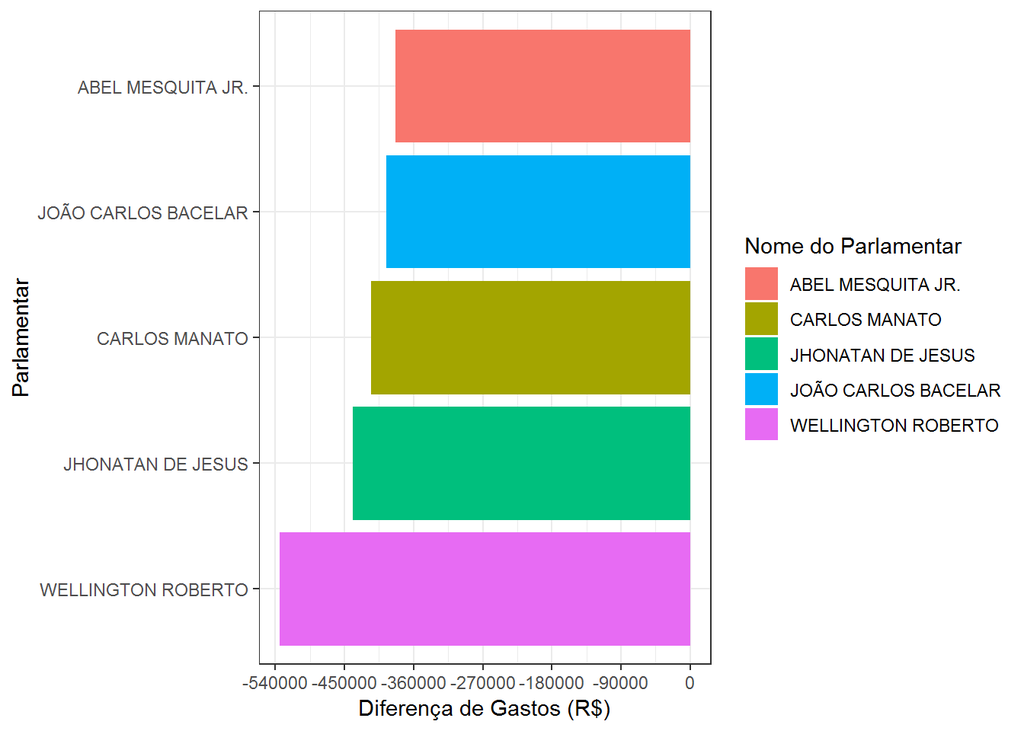

```r
data.limiteMensal %>%
  group_by(sgUF, idCadastro, anoMes,
           nomeParlamentar, limiteMensal) %>%
  summarise(gastoMensal = sum(valorLíquido)) %>%
  filter(anoMes != "NA-NA") %>%
  filter(gastoMensal > limiteMensal) %>%
  ungroup() -> data.gastosMensais

data.gastosMensais %>%
  group_by(nomeParlamentar) %>%
  summarise(diferencaGasto = sum(limiteMensal) - sum(gastoMensal)) %>%
  arrange(diferencaGasto) %>%
  slice(c(1:5)) %>%
  ggplot(aes(x = reorder(nomeParlamentar, diferencaGasto),
             y = diferencaGasto,
             fill = nomeParlamentar)) +
  geom_bar(stat = "identity") +
  scale_y_continuous(breaks = seq(from = 0,
                                to = -540000,
                                by = -90000)) +
  coord_flip() +
  labs(x = "Parlamentar",
       y = "Diferença de Gastos (R$)",
       fill = "Nome do Parlamentar")
```

Na visualização acima temos os 5 primeiros parlamentares que gastam mais do que o limite mensal, podemos perceber que os valores para a **Diferença de Gastos** para cada um deles é bem inferior a **0**, ou seja, a diferença `sum(limiteMensal) - sum(gastoMensal)` é realmente muito desigual, tendo eles gastado bem mais que o limite.

## Quais estados cujos parlamentares gastam mais com passagens aéreas?

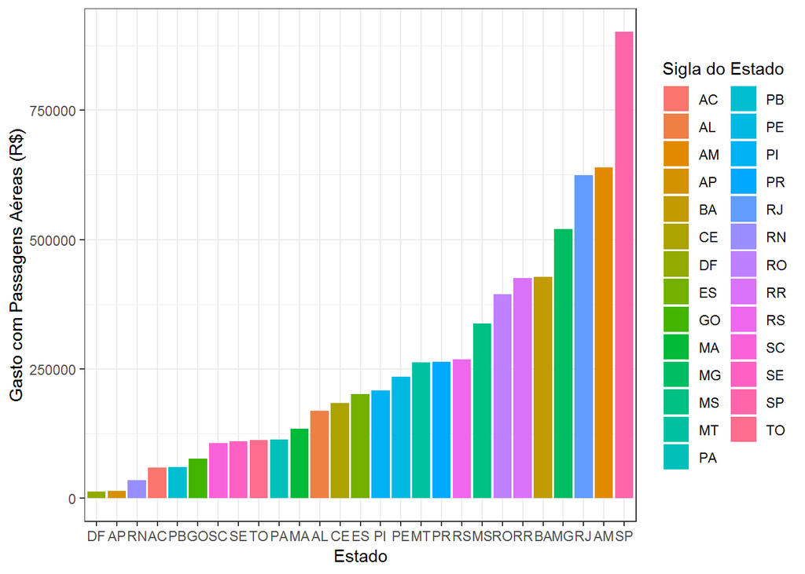

```r
data %>%
  filter(tipoDespesa == "PASSAGENS AÉREAS") %>%
  group_by(sgUF) %>%
  summarize(gastoPassagens = sum(valorLíquido)) %>%
  filter(sgUF != "NA") %>%
  ggplot(aes(x = reorder(sgUF, gastoPassagens),
             y = gastoPassagens,
             fill = sgUF)) +
  geom_bar(stat = "identity") +
  labs(x = "Estado",
       y = "Gasto com Passagens Aéreas (R$)",
       fill = "Sigla do Estado")
```

Dentre os estados acima, os que mais gastam com passagens aéreas são **MG (Minas Gerais)**, **RJ (Rio de Janeiro)**, **AM (Amazonas)**, **SP (São Paulo)**.

## Escolha três partidos e responda: Quais são os tipos de despesa mais utilizados no uso da CEAP pelos deputados desses partidos? Mesma pergunta considerando valores em R$.

Dentre os partidos presentes no nosso conjunto de dados iremos escolher os mais “famosos”: **PT**, **PSDB** e **PMDB**.

### PT

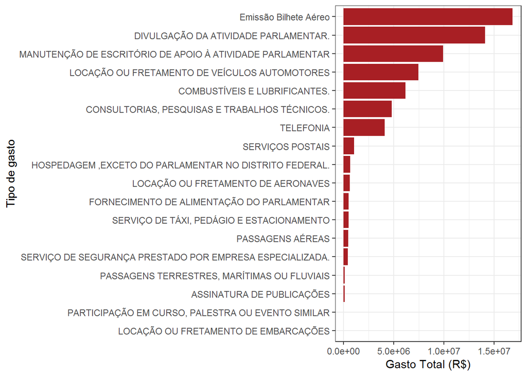

```r
data %>%
  filter(sgPartido %in% c("PT")) %>%
  group_by(tipoDespesa) %>%
  summarize(gastoTotal = sum(valorLíquido)) %>%
  ggplot(aes(x = reorder(tipoDespesa, gastoTotal),
             y = gastoTotal)) +
  geom_bar(stat="identity",
           fill="#A81F24") +
  labs(y = "Gasto Total (R$)",
       x = "Tipo de gasto") +
  coord_flip()
```

É bem fácil percebermos que o partido **PT** possui muitos gastos com **Emissão de Bilhete Aéreo**, mas também tem gastos com **Divulgação da Atividade Parlamentar** e dentre outras tarefas como podemos ver mais acima.

### PSDB

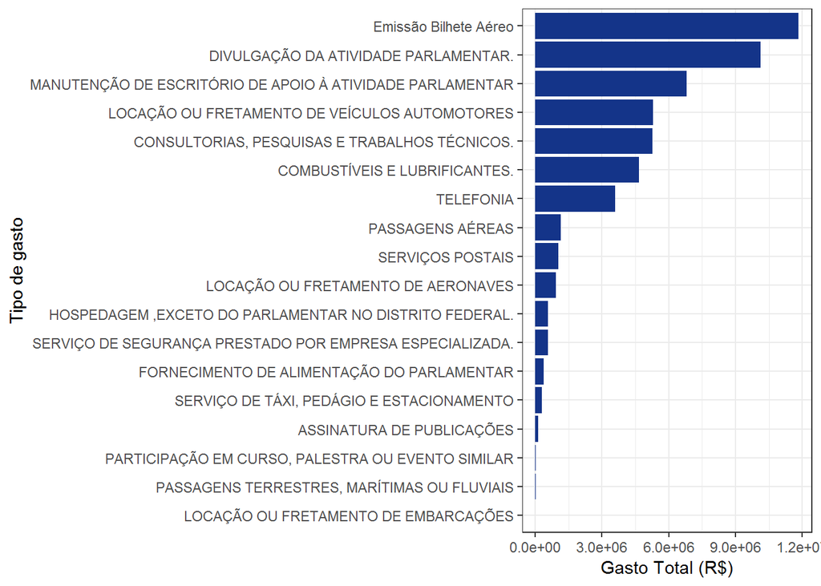

```r
data %>%
  filter(sgPartido %in% c("PSDB")) %>%
  group_by(tipoDespesa) %>%
  summarize(gastoTotal = sum(valorLíquido)) %>%
  ggplot(aes(x = reorder(tipoDespesa, gastoTotal),
             y = gastoTotal)) +
  geom_bar(stat="identity",
           fill="#143489") +
  labs(y = "Gasto Total (R$)",
       x = "Tipo de gasto") +
  coord_flip()
```

De forma bastante semelhante ao **PT**, o **PSDB** possui gastos concentrados em **Emissão de Bilhete Aéreo** com alguns outros gastos na **Divulgação da Atividade Parlamentar**.

### PMDB

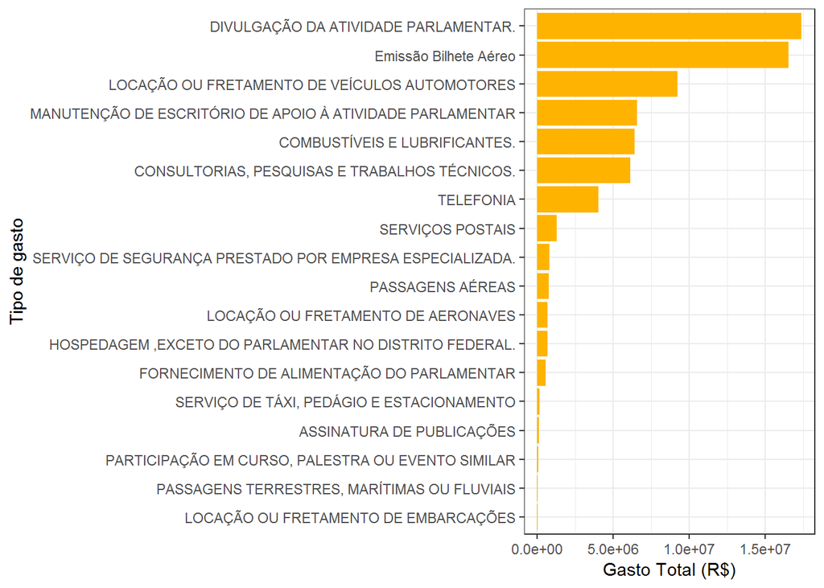

```r
data %>%
  filter(sgPartido %in% c("PMDB")) %>%
  group_by(tipoDespesa) %>%
  summarize(gastoTotal = sum(valorLíquido)) %>%
  ggplot(aes(x = reorder(tipoDespesa, gastoTotal),
             y = gastoTotal)) +
  geom_bar(stat="identity",
           fill="#FFB301") +
  labs(y = "Gasto Total (R$)",
       x = "Tipo de gasto") +
  coord_flip()
```

Para o **PMDB** temos a situação inversa, o maior gasto do partido é com **Divulgação da Atividade Parlamentar** e em seguida, os gastos com **Emissão de Bilhete Aéreo**.

### Conclusão

Desconsiderando esses dois comuns e grandes gastos dos partidos acima, o terceiro ponto em que eles mais gastam o dinheiro é com **Manutenção de Escritório de Apoio à Atividade Parlamentar** para o **PT** e **PSDB** enquanto que para o **PMDB** temos mais gastos com **Locação ou Fretamento de Veículos Automotores**.